# 203 Assignment 1

## Introduction

This assignment is going to use the principles of energy balance to examine how changing properties of urban environments alter the temperature of urban landscapes. In urban areas, the distribution of materials such as asphalt and concrete has been shown to lead to higher air temperatures compared to rural counterparts. This is known as the urban heat island (UHI) effect. High temperatures can be harmful to the health of residents, and in order to mitigate the UHI cities adopt strategies like increasing tree cover to increase shade and cooling, or increasing the reflectivity, also called albedo, with white paint. However, these strategies are not always evenly distributed throughout a city and may create environmental inequity. Read more about this phenomena [here](https://docs.google.com/document/d/1NUJATMo7KnmC3PpyFRdxo9HWH0F-zQxUDKiIW6pX7pY/edit#heading=h.z1slrwcvefnj).

We’ve assembled a dataset that captures a snapshot of average midday temperatures in August, the amount of vegetation, and a host of social/economic data across each neighborhood in the county of Los Angeles. The temperature data is from the Landsat satellite’s surface thermal data and was acquired in the Spring (April) and Summer (August) of 2020. The vegetation data is characterized by the Normalized Difference Vegetation Index (NDVI), and is taken from similar dates. [NDVI](https://earthobservatory.nasa.gov/features/MeasuringVegetation/measuring_vegetation_2.php) is a measure of “greenness” and higher values of NDVI indicate a greater amount of green vegetation within each neighborhood. The neighborhood information is collated from the incredibly awesome Mapping LA project developed by the [LA Times](http://maps.latimes.com/neighborhoods), which is worth checking out. See a description of each column in the dataset at this [link](https://docs.google.com/spreadsheets/d/1Hh-hMt5RuXA3lBYX8G16T3334zXQfbFnJzCxh3qbDsw/edit#gid=0)

**Note**: For those of you new to southern CA, August is the height of the mediterranean dry season, and it usually doesn’t rain much (if at all) between May and October. This means that the data on vegetation you are seeing must be associated with irrigated lawns, gardens, or parks and open spaces with numerous deeply-rooted trees.

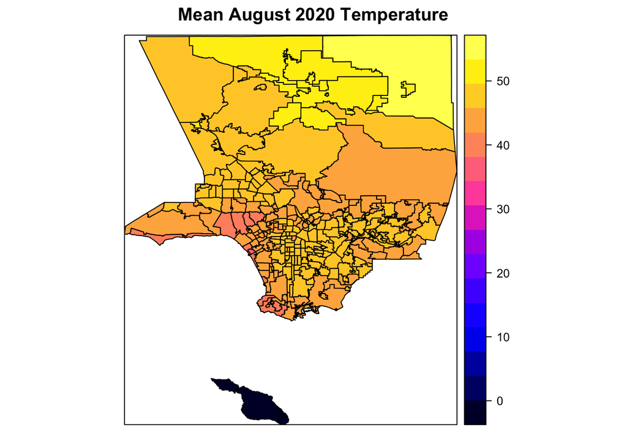

```r
# load shapefile - this contains map of neighborhoods
losang <- shapefile("CPT/data/ESM203_F2020_Ass1.shp")

# view spatially averaged temperature
spplot(losang, 'TEMP_SUMME', main="Mean August 2020 Temperature")
```

```r
## chose a different variable and plot it here (can check other variables by typing 'names(losang)' in the console)
```

### Observations

Let’s start by just exploring our data. One of the first things we’d want to explore is what data is there. Run the code below to load the data and output the column names of all the data.

```r
# load in data as a CSV
LA_nbhds <- read.csv("CPT/data/ESM203_F2020_Ass1.csv")
colnames(LA_nbhds)
```

```
##  [1] "NEIGHBORHOOD"        "POPULATION.PER.SQMI" "SINGLE.PARENTS"
##  [4] "ASIAN.POPULATION"    "LATINO.POPULATION"   "WHITE.POPULATION"
##  [7] "CRIME.PER.CAPITA"    "CRIME.TOTAL"         "DIVERSITY.INDEX"
## [10] "MEDIAN.INCOME"       "HOMEOWNERS"          "BLACK.POPULATION"
## [13] "NDVI_SPRING"         "NDVI_SUMMER"         "TEMP_SPRING"
## [16] "TEMP_SUMMER"
```

Let’s say you spent the evening playing around with the data looking for trends. Ideally we’d have a hypothesis in mind that we wanted to test, but sometimes in science you get lucky and stumble upon your hypothesis. So you were plotting variables against each other to see if there were any obvious trends

So we plot Mean August 2020 Temperature against Summer NDVI. We notice that this trend looks somewhat promising, and decide to plot a trendline. Do this by running the code below.

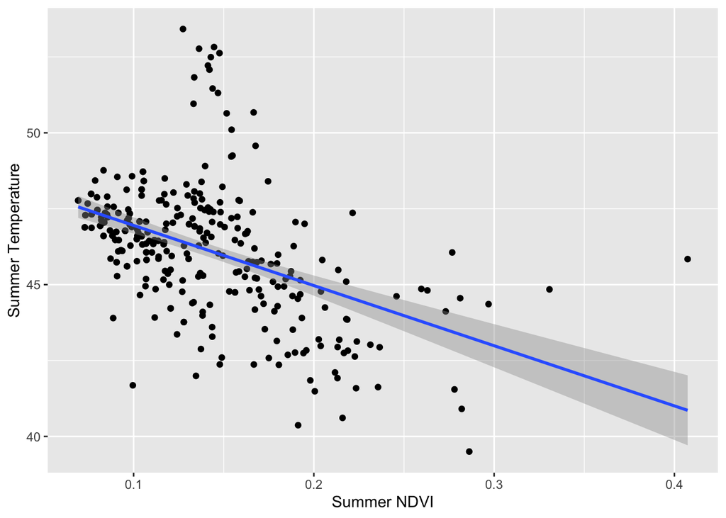

```r
# load in data as a CSV
LA_nbhds <- read.csv("CPT/data/ESM203_F2020_Ass1.csv")

LA_nbhds %>%
  dplyr::filter(NDVI_SUMMER > 0 & NDVI_SUMMER < 1) %>%
  ggplot() + geom_jitter(aes(x=NDVI_SUMMER, y=TEMP_SUMMER)) +
  geom_smooth(aes(x=NDVI_SUMMER, y=TEMP_SUMMER), method=lm) +
  labs(x = "Summer NDVI", y="Summer Temperature")
```

#### Answer these questions:

Describe the relationship between August 2020 Mean Temperature and NDVI

What might be some possible explanations as to why this relationship exists. Theres no right answer here, go wild with it.

Now based upon your explanation form a single statement here, which we will use the model to test. This is your hypothesis. There is no “right answer,” so please dont go back and change this.

### Understanding the model

We’re gonna be using equations throughout this class, so lets learn how to become more literate in equations. To do this we’re going to explain the parameters in words and then draw a conceputal model. This may take some time, but its an extremely important skill. So take a deep breath, be patient with yourself, and dive in.

Here is the somewhat simplified equation we will be using. Please write a description below of what each flux is.

$$Q_{av} = L_{out} + \frac{(\Delta T)}{r_H} + \frac{(\Delta e)}{r_W}$$

#### Answer these questions:

Define the terms of the equation. If you need a hint, check out this chapter on [surface energy fluxes](https://gauchospace.ucsb.edu/courses/pluginfile.php/10694510/mod_resource/content/2/Reading%20for%20Surface%20Energy%20Balance.pdf).

$Q_{av}$

$L_{out}$

$\frac{(\Delta T)}{r_H}$

$\frac{(\Delta e)}{r_W}$

#### Answer these questions:

Draw a conceptual model. If you’re unsure what a conceptual model is please reference the slides or google it, and a hint—you’ve seen the conceptual model you should be drawing before.

Draw the conceputal model on the computer or by hand. If drawn by hand take a photo on your phone. If drawn on the computer make sure it is saved as some type of photo format (ex- .jpg or .png) Put the photo in the folder for this assignment, and add the name of the image below, where it indicates. Alternatively, if you drag a drop the photo into RStudio, it will write the pathway for you.

### Surface Energy Balance - Solving for surface temperature

The chunk below consists of functions needed to do the assignment. No need to change or do anything here, just run this chunk so the equations can be used below.

```r
# the following functions are needed to solve the surface energy balance and calculate latent heat

# Tetens eq. to solve for saturated vapor pressure (used in LE eq.)
sat_vp <- function(T){
  e <- 0.61078*exp(17.27*T/(T+237.3))
  return(e)
}

# surface energy balance returns surface temperature
# input is surface temperature, represented as x (in celsius)
# veg represents % veg cover, alpha is albedo, and eps is emissivity
seb <- function(x, veg=0, alpha=0.15, eps=0.95){
  r_w = 1/(veg*50) # scaler for veg
  L_inc = 0.9 * sigma * (T_a+273.15)^4  # W/m^2, incoming longwave radiation
Q_av = 0.9 * (K_inc*(1-alpha) + L_inc) # W/m^2
  k = Q_av
  L = eps*sigma*(x+273.15)^4
  Qh = 1.15*1005*(x-T_a)/r_H # sensible heat flux
  Qe = 1.15*1005/66.5*(sat_vp(x) - sat_vp(T_a))/r_w # latent heat flux
  val = - k + L + Qh + Qe
  return(val)
}

## returns bar plot of the different fluxes
plot_fluxes <- function(veg){
  alpha=0.2
  range=c(1,100)
  x <- uniroot.all(seb, range, veg=veg, alpha=0.2)
  L_inc = 0.9 * sigma * (T_a+273.15)^4  # W/m^2, incoming Longwave
  Q_av = 0.9 * (K_inc*(1-alpha) + L_inc) # W/m^2, net radiation
  k = Q_av
  r_w = 1/(50*veg) # scaler for veg
  L = 0.95*sigma*(x+273.15)^4
  Qh = 1.15*1005*(x-T_a)/r_H
  Qe = 1.15*1005/66.5*(sat_vp(x) - sat_vp(T_a))/r_w
  fluxes <- data.frame(flux=c("k","L","Qh","Qe"), value=c(k,L,Qh,Qe))
  plot <- ggplot(fluxes) + geom_col(aes(x=flux, y=value, fill=flux))
  return(plot)
}
```

In order to use this equation to test our hypothesis we are going to do a sensivitiy analysis. To perform this, we vary one parameter and observe how the output changes, which in this case is temperature. We’re first going to do an example together, and then you’re’ll do one on your own.

### Albedo

We learned in class that albedo affects the amount of shortwave radation entering the surface by reflecting some back. Albedo affects the available energy at the surface, $Q_{av}$ through the equations:

$$S_{net} = (S_{\downarrow}*(1-\alpha)$$

Where $\alpha$ represents albedo. Use the code below to explore the model outcomes, and to answer the questions below.

The following are other variables needed to use the model. No need to change these.

```r
T_a = 28 # ambient atm temp in Celsius
sigma = 5.6704*10^-8 #W/m^2/K^4 stefan-boltzmann constant
r_H = 20 # Sensible heat resistivity
K_inc = 800 # W/m^2, incoming shortwave radiation
```

```r
## Run the below code to solve for surface temperature
# temp_s is surface temperature
range = c(0,100)
test_albedo <- function(x){
  temp_s = uniroot.all(seb, range, alpha=x)
  return(temp_s)
}

# You can solve for surface temp by inputting specific values of albedo, where x is albedo - replace x with any value between 0 and 1.
test_albedo(x=0.9)
```

```
## [1] 28.10527
```

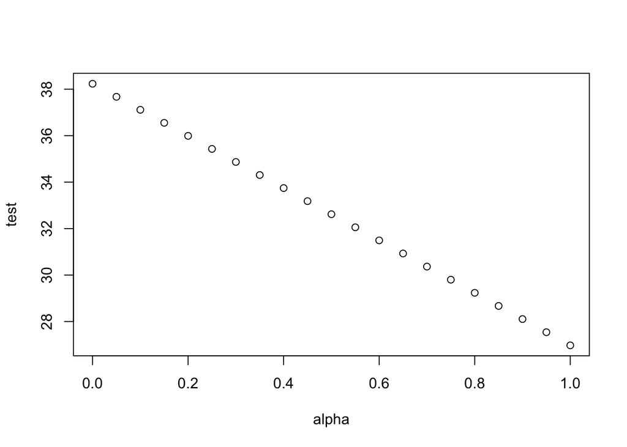

```r
# The code below runs the above function for every value of albedo in the 'alpha' vector below
# quick SA for veg parameter
alpha <- seq(0,1, by=0.05)
test <- sapply(X=alpha, FUN=test_albedo)
# plot veg v. temp
plot(alpha, test)
```

#### Answer these questions:

What happens to the surface temperature when albedo increases?

Think about a roof made of asphalt, and a roof that has been painted white. Which would have a higher albedo? Which would have a higher surface temperature?

### Vegetation

Now its your turn do a sensitivity analysis based upon the amount of vegetation.

Remember that we defined latent energy as:

$$\lambda E \propto \frac{\Delta e}{r_W}$$

But in reality, it’s a bit more complicated:

$$\lambda E = -\frac{\rho*C_p}{\gamma}*\frac{e_a - e_{*}[T_s]}{r_W}$$

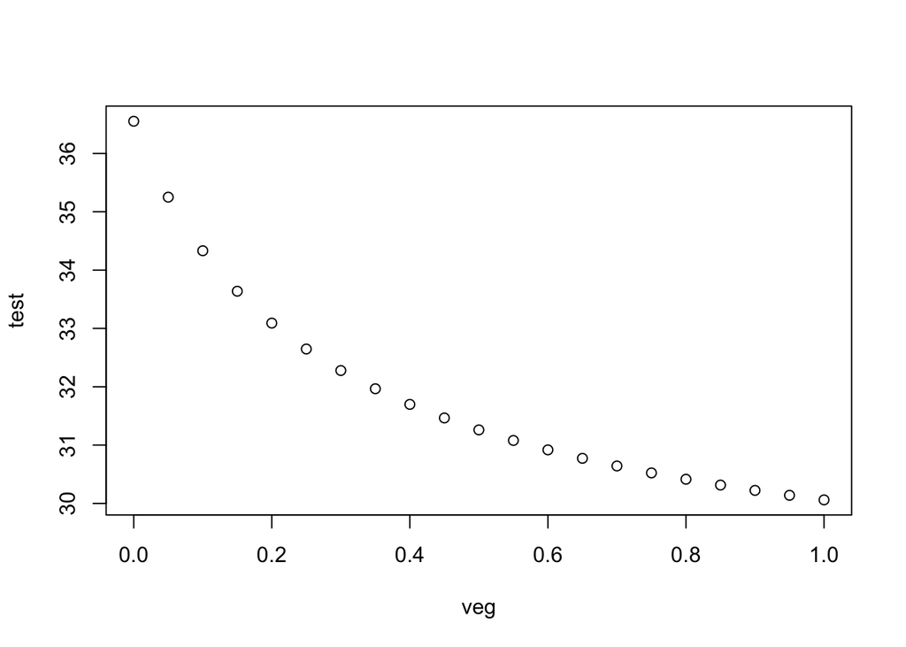

```r
## Run the below code to solve for surface temperature
# temp_s is surface temperature
range = c(0,100)
test_veg <- function(veg){
  temp_s = uniroot.all(seb, range, veg=veg)
  return(temp_s)
}

# quick SA for veg parameter
veg <- seq(0,1, by=0.05)
test <- sapply(X=veg, FUN=test_veg)
plot(veg, test) # plot veg v. temp
```

We have created a function that lets you plot the different energy fluxes based on the amount of vegetation. Use this tool to help conceptualize the results of your sensitivity analysis above.

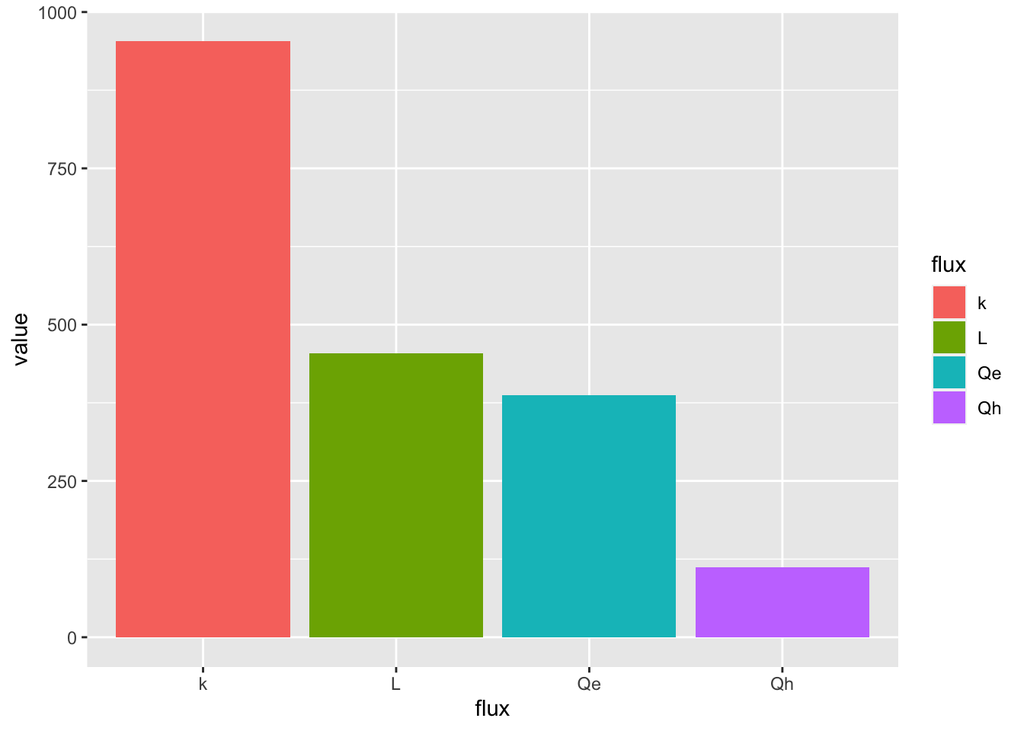

```r
# plot_fluxes shows a bar plot of the different energy fluxes. Change veg between 0 to 1 to see how the latent and sensible energy change
plot_fluxes(veg=1)
```

#### Answer these questions:

How does the presence of vegetation affect the surface temperature?

Explain why this relationship occurs.

Does this relationship explain the initial graph between NDVI and temperature above? Explain.

### Socioeconomic data

Remember the NDVI. v. Temperature plot above? Now it’s your turn to explore the data set (`LA_nbhds`) and create your own plots. You can use anything you’ve learned from 206 so far to explore and summarize the data. Create at least one plot that includes NDVI or temperature on the x-axis, and a socio-economic variable on the y-axis. You can copy and paste the code from above, but also be creative! Then answer the reflection questions below.

```r
## plot here
```

1. Based on your plot(s) what relationship exists? Write a short (1-2 paragraph max) reaction/response to your findings, focusing on what they imply for issues related to environmental management, planning, and/or environmental justice. While your response should refer to the specifics of your plots/presentation, you do not need to do an exhaustive analysis or find citations to support your inference.